# Interactive data visualisation

DATA5002 Lectorial Week 7

# Assignments

## Assignment 1 comments

### Common problems in Assignment 1

General

- Carefully read all instructions, course announcements, and rubric.
- Every plot should be include informative title, axis labels, units (especially for an external audience).
- This class is not just about creating plots, but also understanding and interpreting plots, and distilling the message/conclusion of a plot.

### Question 1

- Choose a graph appropriate for the audience.
  - For public consumption: bar chart or another simple chart.
  - For scientific audience: boxplot, violin plot, etc (better to provide more detail if you can)

### Question 2 and 3

Question 2

- You should be able to look at a plot and highlight a few key insights using the visual information.

Question 3

- Don’t neglect the statistics aspect: choosing appropriate variables for a model, deciding whether or not they should be included as factor or numeric.
- Diagnostic plots: even if a graph shows a small violation, it is better to mention it than to say the graph looks fine, even if you conclude that linear regression is okay in this case. This promotes honesty.
- Forest plot: if a term has been introduced in class, use examples from course materials, not from googling.

### Improvements in Assignment 1

- Consider how best to use colour:
  - As an aesthetic to encode categories (but avoid colour-blind-unfriendly palette choices).
  - To highlight something important.
  - Avoid redundant rainbow colour palette for pure aesthetics (this is generally considered distracting chartjunk).
- Consider orderings besides the default (such as ordering bars from highest to lowest, rather than pizza brand letter).
- Consider whether wrangling or augmenting data would produce data that is more interpretable to the audience. Don’t assume the data as given to you is the best representation.

## Assignment 2 (project)

### Overview

- Create a narrative infographic/scrollytelling article or interactive dashboard (or something in between).
- Suitable for a portfolio (depending how good you make it).
- Goal: unsuitable projects filtered out at proposal stage.
- Use R or another reproducible programming language (not Tableau).

### Overview

Loosely, should be on the spectrum:

|  | narrative infographic | ⟺ | interactive dashboard |
| --- | --- | --- | --- |
| **format** | image or static page | ⟺ | application |
| **UX** | linear narrative | ⟺ | exploration |
| **aesthetics** | artistic | ⟺ | practical |
| **audience** | general | ⟺ | knowledgeable |

Note that most of the above is negotiable to a point. Any deviations from above should be brought up in the proposal stage.

### Thoughts on Shiny

- If creating a shiny project, create a minimum viable project (MVP) first.
- Especially if data is big (or even medium), test out on a small subset of data until far along in the development process.
- Then, add more graphs, complexity, or customisation one piece at a time.
- Debugging in shiny is harder than debugging a standard R script.
- Consider using a version control software like git/github (built into Rstudio).

### Logistics

**Proposal**

- Submit by the end of Week 8.
- A wireframe, a short writeup, and any “prior art” you can find.
- Proposals may be rejected for being:
  - Too simple
  - Too similar to another project
  - Too similar to existing public materials
- It is your responsibility to ensure that your project is feasible.
- If you submit a proposal, work on project, and find it is infeasible, you can re-submit a new proposal (before end of Week 8).

### Project progress

Progress

- You already have all skills needed to create a static narrative infographic.
- This week: additional skill of interactive graphics.
- Next week: shiny and dashboards.
- No matter what you want to create, you can already begin coding (once proposal is approved). - Data processing and wrangling. - Create the individual plots you want to include in your project. - Later: make them interactive, and/or arrange them into a dashboard.

. . .

**Final submission**

- Format depends on project type.
- Include a short report explaining how and why you did what you did.

# Interaction design

## Principles

### Dimensions

[Siang (2020)](https://www.interaction-design.org/literature/article/what-is-interaction-design)

1. Words
2. Visual representations
3. Physical objects or space
4. Time
5. Behaviour

### Questions to consider

- What can a user do to directly interact with the interface?
- What about the appearance gives the user a clue about how it may function?
- Are the interface elements a reasonable size to interact with?
- Are familiar or standard formats used?

. . .

- Examples of error messages: `ggplot(mtcars, aes(wt, mpg)) %>% geom_point()`
- Examples of feedback: If recalculation takes a while, make sure the user is aware that the system is responsive.

Also,

- Are error messages informative and useful?
- What feedback does a user get once an action is performed?

### Examples

- [Shiny Gallery](https://shiny.rstudio.com/gallery/)

## Wireframing

### Overview

[Snow (2012)](https://www.linkedin.com/learning/infographics-planning-and-wireframing/intro-to-planning-and-wireframing?) | [Emery (2016)](https://depictdatastudio.com/how-to-sketch-doodle-and-draw-data-visualization-drafts-by-hand/) | [Osder (2016)](https://www.linkedin.com/learning/omnigraffle-6-for-ux-design/what-is-a-wireframe)

- high-level ideation
- structure and main elements
- assist in designing UI, help navigation
- general tool for UX design, useful for data vis.

. . .

- diagram of page layout
- layout of elements, hierarchy, allocation of space
- not actual design work: represent pictures with boxes
- indicate relative sizes, fonts, but not actual fonts or colours

### Example: DATA5002 Moodle page

[figure not shown]

### Example: blog wireframes

[Brooke](http://brookecanhaztaco.blogspot.com/2013/01/personal-website-wireframe-sketches.html)

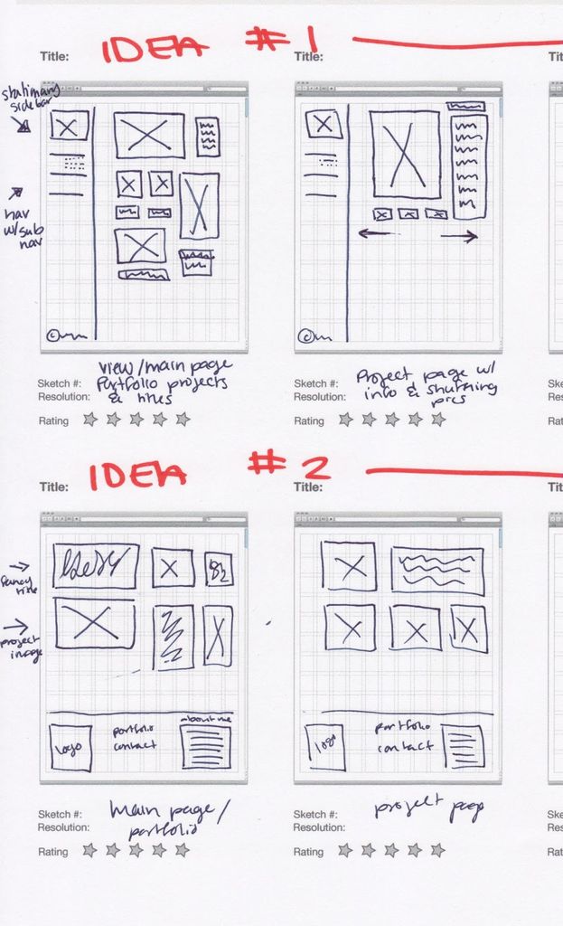

## Visualisation heuristics

### Purpose

[Williams (2018)](https://link.springer.com/chapter/10.1007/978-3-319-91238-7_18)  
Forsell and Johansson (2010)

- Things to pay attention to
- Predict and preempt usability issues for visualisations:
  - Evaluate and adjust plans (e.g., wireframe) before putting in the work.
  - Prevent usability issues before they emerge.

. . .

The article:

- 10 heuristics, 5 visualisations, 10 participants
- Participants evaluate visualisations according to heuristics
- “Baseline” evaluation as well

. . .

- Essentially, testing inter-rater reliability of heuristics

### Heuristics (1–4)

**H1 Spatial organization**

- overall layout
- ease of locating info elements
- awareness of overall distribution of info elements

**H2 Information coding**

- mapping data elements to visual elements
- symbols/characteristics for alternative representations

**H3 Orientation and Help**

- user control over level of detail
- redo/undo of user actions
- breadcrumbs

**H4 Data set reduction**

- focusing and filtering
- clustering
- pruning

### Heuristics (5–8)

**H5 Recognition rather than recall**

- user not required to remember
- easy access to instructions

**H6 Remove the extraneous**

- largest amount of data with least amount of ink

**H7 Prompting**

- discoverability of interactive elements
- which alternatives are available in a context
- system status information

**H8 Minimal actions**

- as few steps as possible to accomplish a task

### Heuristics (9–10)

**H9 Consistency**

- similarity of design choices in similar contexts
- differences in different contexts

**H10 Flexibility**

- adaptability to user’s needs

Which of the above are specific to interactive visualisation?

### V1: Scatterplot

[Williams (2018)](https://link.springer.com/chapter/10.1007/978-3-319-91238-7_18)

**Question:**

Which vessel type had the highest death per passenger ratio?

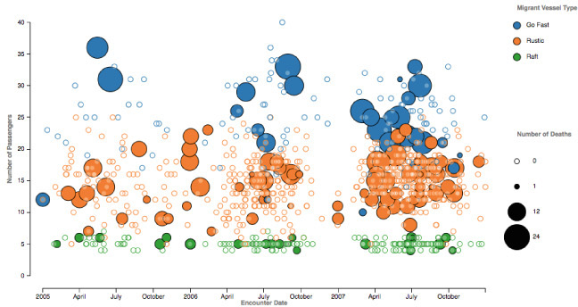

### V1: Heuristics

[Williams (2018)](https://link.springer.com/chapter/10.1007/978-3-319-91238-7_18)

**H1**

Occlusion: Difficult to see individual points

**H2**

Date axis compressed and difficult to read

**H5**

Difficult to compare dot size from diﬀerent months

**H5**

Difficult to verify that 24 is the largest number of deaths? (There seem to be sizes that do not correspond to the 0, 1, 12, 24 in the legend)

**H2, H8**

Scales do not help answer the question directly (which vessel type has the highest death per passenger ratio), requires mental math

### V2: Sunburst

[Williams (2018)](https://link.springer.com/chapter/10.1007/978-3-319-91238-7_18)

**Question:**

Which vessel type had the most cumulative passengers?

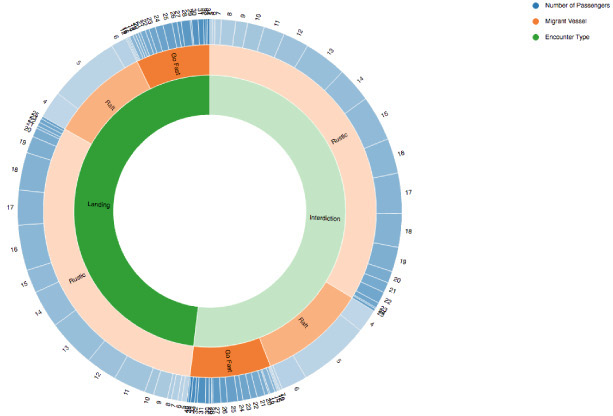

### V2: Heuristics

[Williams (2018)](https://link.springer.com/chapter/10.1007/978-3-319-91238-7_18)

**H1**

Vessel types are not contiguous which makes it difficult to count passengers (add from two parts in the display, both landing + interdiction)

**H1**

Numbers occlude, are difficult to read in Go Fast vessel type

**H9**

Blue is inconsistent within a vessel type and the variation does not mean anything (is it that the number of passengers ∼ opacity?)

### V3: Tree Map

[Williams (2018)](https://link.springer.com/chapter/10.1007/978-3-319-91238-7_18)

**Question:**

Which vessel type had the most cumulative passengers?

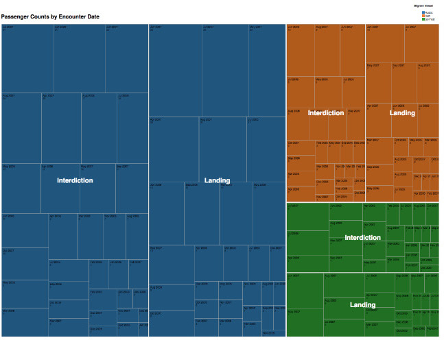

### V3: Heuristics

[Williams (2018)](https://link.springer.com/chapter/10.1007/978-3-319-91238-7_18)

**H1**

Labels occlude each other a little bit

**H3**

Passenger count not labeled

**H2**

Shape of vessel of same passenger count is not consistent (comparing squares and rectangles)

**H8**

Have to add to get total passengers

### V4: Parallel Sets

[Williams (2018)](https://link.springer.com/chapter/10.1007/978-3-319-91238-7_18)

**Question:**

Which vessel type had the highest death per passenger ratio?

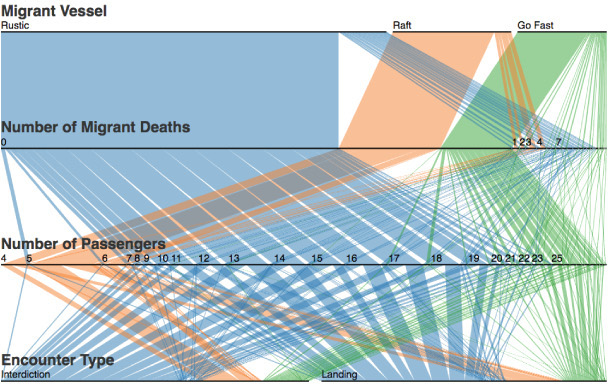

### V4: Heuristics

[Williams (2018)](https://link.springer.com/chapter/10.1007/978-3-319-91238-7_18)

**H3**

Number of deaths impossible to read (only labels 0, 1, 2, 3, 4, and 7, have to guess at the others)

**H3**

Number of passengers impossible to read (there are not enough labels at far right end)

**H1**

Connecting Death to Passengers requires following a thin line

**H8**

Still need mental math to answer ratio question

**H1**

Line crossings difficult to follow

### V5: Area Plot

[Williams (2018)](https://link.springer.com/chapter/10.1007/978-3-319-91238-7_18)

**Question:**

Which vessel type had the highest cumulative deaths?

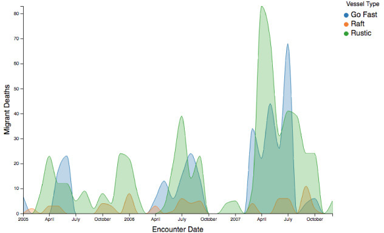

### V5: Heuristics

[Williams (2018)](https://link.springer.com/chapter/10.1007/978-3-319-91238-7_18)

**H8, H6**

Requires mental math to get cumulative deaths (sum area under curve)

**H6**

Labels are not precise enough for exact math

**H2**

Continuous lines and area makes it difficult to know how to do the addition (i.e., ﬂat portion of raft for April 2005, how many 4 s do we add?)

**H2**

Viz better suited for relative comparison than precise reading

# Tools

### In this course…

- `htmlwidgets`
- `shiny`
- Tableau

## `htmlwidgets`

A family of R packages for JavaScript-based visualisations

### Mechanism

1. Embed `htmlwidget` R code into an Rmarkdown document chunk.
2. Render document to HTML to insert JavaScript code into the result.
3. View the HTML in the browser; JavaScript provides interaction.

. . .

No R in the final product!

### Typical functionality

- Query interesting points
- Zoom in on regions
- Rearrange elements for better visibility
- Rotate 3D plots

### Advantages and disadvantages

**+**

Quick interactive visualisation

**+**

End-user doesn’t have to run R

. . .

**−**

Limited customisation: controls and UI limited to what’s in the library

### Some available widget packages

[htmlwidges.org showcase](https://www.htmlwidgets.org/showcase_leaflet.html)

[ggiraph](https://davidgohel.github.io/ggiraph/)

**`plotly`, `metricsgraphics`, `highcharter`, `rbokeh`**

Interactive graphics using various JS libraries each offering a variety of plots; some can wrap normal `ggplot`s to make them interactive.

**`leaflet`**

Interactive maps and choropleths

**`dygraphs`**

Interactive time series

**`visNetwork`, `networkD3`**

Network data visualisation

**`DT`**

Tabular data

**`threejs`, `rglwidget`**

rotatable 3D

**`ggiraph`**

## `shiny`

A toolkit for creating dashboards in R

### Model–View–Controller

[Wikipedia](https://en.wikipedia.org/wiki/Model%E2%80%93view%E2%80%93controller)

#### Software components

**Model**

Data structures representing application state (independent of UI)

**View**

Visual representation of the application state

**Controller**

Takes inputs from user

#### Interactions

[figure not shown]

### Mechanism

Specify:

**R environment (Model)**

data, variables, etc.

**`UI` elements (View and Controller)**

sliders, selectors, boxes, buttons, *plots*. Plots can themselves be `htmlwidgets` or other interactive elements.

**`server` code (Interactions)**

declarations “reacting” to UI interactions to update the graphics

. . .

- UI delivered via HTML/JavaScript in browser
- Talks to an R session in the background
- Requires an R “server” to be running

### Aside: Declarative programming

#### Imperative programming

Computer,

1. Do this
2. Next do this
3. Next do this

#### Declarative programming

Computer, here’s what I want:

- Goal/constraint
- Another goal/constraint
- Another goal/constraint

. . .

Computer, **you** figure out how to best achieve them.

### Declarative programming examples

Often domain-specific.

**Structured Query Language (`SQL`)**

“I want the table rows that satisfy these criteria. Computer, figure out the quickest way to find them.”

. . .

**`BUGS`/`JAGS`/`STAN`**

“Here’s a specification of conditional distributions between these variables. Computer, figure out how to sample from them.”

**`HTML`**

“Here’s the text and the semantic and formatting information. Computer, figure out how to render it on the screen.”

**linear programs**

“Here’s the linear function of $x$ and the set of constraints on $x$. Computer, figure out how to find the optimum.”

. . .

**`shiny`**

“Here are the UI components and how I want the program to react to their inputs. Computer, figure out how to make it work.”

### Tiny `shiny` example

```r
library(shiny)

# Layout type
ui <- fluidPage(
  # Number input widget, appears in server() as input$n
  numericInput("n", "n", 1),
  # Plot output widget, server() can update it by assigning to output$plot
  plotOutput("plot")
)

server <- function(input, output)
{
  # Put the following plot into the "plot" widget:
  output$plot <- renderPlot({
    par(mar = c(0,0,0,0))
    # Plot some points
    plot(1:input$n)
    # With these dimensions
  }, width = 400, height = 400)
}

# Computer, make it all work.
shinyApp(ui, server)
```

### Shiny: advantages and disadvantages

**+**

Can make use of all capabilities of R and its packages

**+**

A variety of flexible controls

**+**

Can embed and interact with `htmlwidgets`

**+**

R can run on a server or the cloud (e.g., [`https://shinyapps.io`](https://shinyapps.io))

. . .

**−**

Requires *someone* to run the R back-end

**−**

Can be slow

**−**

Requires writing code for the interaction

## Tableau

A proprietary program and framework providing a GUI for creating dashboards.

### Mechanism

1. Start the application.
2. Connect it to data source(s).
3. Use drag-and-drop interface to design the dash board.
4. (Optionally) Run the dashboard server (locally, on a server, and/or the cloud) and access the dashboard runs in a browser.

### Examples

[Tableau Desktop](https://www.tableau.com/academic/students) | [Some web dashboards](https://www.tableau.com/data-insights/dashboard-showcase)

[figure not shown]

### Tableau: advantages and disadvantages

**+**

Point-and-click interface

**+**

Integrates with a variety of data sources and processing systems

**+**

Can handle big datasets well (if back-end can)

**+**

Public dashboards can be hosted for free (for now)

. . .

**−**

Point-and-click interface

**−**

Proprietary: must pay for non-educational use

**−**

Capabilities limited to what Tableau developers produce

### Conclusion

Reminder

- Project proposal due by Friday of Week 8!

Looking forward:

- Week 8: Dashboards (last week relating to project)
- Week 9: Visualisation in machine learning
- Week 10: Graphs for specific contexts (including possibly social networks, time series, animation, text, or other topics)
- Feel free to continue suggesting specific topics for Weeks 9-10

### Consultation hours

Extra consultation hours for project discussions for the remainder of the course (Weeks 7 - 10).

- Tuesday, 11 AM - 12 PM (Zoom), 1 PM - 2 PM (Zoom or H13 Anita B Lawrence Centre East 2074).
- Thursday, 1 PM - 2 PM (Zoom or H13 Anita B Lawrence Centre East 2074).
- Masks required for in-person consultation.
- Also available by appointment.
- Hours may be changed in future weeks (announcement will be made).